# White Wines

Alexandre Medeiros Gonçalves

May 12, 2016

## Input variables and their relation with quality.

### Load and initial statistics

First I load the dataset take a have a quick overview:

```
## [1] 4898   13
```

```
## 'data.frame':    4898 obs. of  13 variables:
##  $ X                   : int  1 2 3 4 5 6 7 8 9 10 ...
##  $ fixed.acidity       : num  7 6.3 8.1 7.2 7.2 8.1 6.2 7 6.3 8.1 ...
##  $ volatile.acidity    : num  0.27 0.3 0.28 0.23 0.23 0.28 0.32 0.27 0.3 0.22 ...
##  $ citric.acid         : num  0.36 0.34 0.4 0.32 0.32 0.4 0.16 0.36 0.34 0.43 ...
##  $ residual.sugar      : num  20.7 1.6 6.9 8.5 8.5 6.9 7 20.7 1.6 1.5 ...
##  $ chlorides           : num  0.045 0.049 0.05 0.058 0.058 0.05 0.045 0.045 0.049 0.044 ...
##  $ free.sulfur.dioxide : num  45 14 30 47 47 30 30 45 14 28 ...
##  $ total.sulfur.dioxide: num  170 132 97 186 186 97 136 170 132 129 ...
##  $ density             : num  1.001 0.994 0.995 0.996 0.996 ...
##  $ pH                  : num  3 3.3 3.26 3.19 3.19 3.26 3.18 3 3.3 3.22 ...
##  $ sulphates           : num  0.45 0.49 0.44 0.4 0.4 0.44 0.47 0.45 0.49 0.45 ...
##  $ alcohol             : num  8.8 9.5 10.1 9.9 9.9 10.1 9.6 8.8 9.5 11 ...
##  $ quality             : int  6 6 6 6 6 6 6 6 6 6 ...
```

### Wrangling

Next we do some small wrangling on the dataset. We reorder variables by meaning based on information from dataset. We build three sets of input variables as following:

- fixed.acidity, volatile.acidity, citric.acidity, pH;
- free.sulfur.dioxide, total.sulfur.dioxide, sulphates;
- density, alcohol, residual.sugar, chlorides

We also drop the X variable and create a factor version of the quality variable. Finally we set all measurement units to $\frac{g}{dm^3}$, so we can make numerical comparisons if needed (except alcohol, which is in volume percentage).

```
##   fixed.acidity volatile.acidity citric.acid   pH free.sulfur.dioxide
## 1           7.0             0.27        0.36 3.00               0.045
## 2           6.3             0.30        0.34 3.30               0.014
## 3           8.1             0.28        0.40 3.26               0.030
## 4           7.2             0.23        0.32 3.19               0.047
## 5           7.2             0.23        0.32 3.19               0.047
## 6           8.1             0.28        0.40 3.26               0.030
##   total.sulfur.dioxide sulphates density chlorides alcohol residual.sugar
## 1                0.170      0.45  1001.0     0.045     8.8           20.7
## 2                0.132      0.49   994.0     0.049     9.5            1.6
## 3                0.097      0.44   995.1     0.050    10.1            6.9
## 4                0.186      0.40   995.6     0.058     9.9            8.5
## 5                0.186      0.40   995.6     0.058     9.9            8.5
## 6                0.097      0.44   995.1     0.050    10.1            6.9
##   quality qualityfact
## 1       6           6
## 2       6           6
## 3       6           6
## 4       6           6
## 5       6           6
## 6       6           6
```

A quick overview of statistics.

```
##  fixed.acidity    volatile.acidity  citric.acid           pH
##  Min.   : 3.800   Min.   :0.0800   Min.   :0.0000   Min.   :2.720
##  1st Qu.: 6.300   1st Qu.:0.2100   1st Qu.:0.2700   1st Qu.:3.090
##  Median : 6.800   Median :0.2600   Median :0.3200   Median :3.180
##  Mean   : 6.855   Mean   :0.2782   Mean   :0.3342   Mean   :3.188
##  3rd Qu.: 7.300   3rd Qu.:0.3200   3rd Qu.:0.3900   3rd Qu.:3.280
##  Max.   :14.200   Max.   :1.1000   Max.   :1.6600   Max.   :3.820
##
##  free.sulfur.dioxide total.sulfur.dioxide   sulphates
##  Min.   :0.00200     Min.   :0.0090       Min.   :0.2200
##  1st Qu.:0.02300     1st Qu.:0.1080       1st Qu.:0.4100
##  Median :0.03400     Median :0.1340       Median :0.4700
##  Mean   :0.03531     Mean   :0.1384       Mean   :0.4898
##  3rd Qu.:0.04600     3rd Qu.:0.1670       3rd Qu.:0.5500
##  Max.   :0.28900     Max.   :0.4400       Max.   :1.0800
##
##     density         chlorides          alcohol      residual.sugar
##  Min.   : 987.1   Min.   :0.00900   Min.   : 8.00   Min.   : 0.600
##  1st Qu.: 991.7   1st Qu.:0.03600   1st Qu.: 9.50   1st Qu.: 1.700
##  Median : 993.7   Median :0.04300   Median :10.40   Median : 5.200
##  Mean   : 994.0   Mean   :0.04577   Mean   :10.51   Mean   : 6.391
##  3rd Qu.: 996.1   3rd Qu.:0.05000   3rd Qu.:11.40   3rd Qu.: 9.900
##  Max.   :1039.0   Max.   :0.34600   Max.   :14.20   Max.   :65.800
##
##     quality      qualityfact
##  Min.   :3.000   3:  20
##  1st Qu.:5.000   4: 163
##  Median :6.000   5:1457
##  Mean   :5.878   6:2198
##  3rd Qu.:6.000   7: 880
##  Max.   :9.000   8: 175
##                  9:   5
```

We first notice that median and mean values are very similar, except for residual.sugar variable, which hints to normally distributed variables. The qualityfact variable is also very interesting. It tells us that there are only 20 wines of quality 3, and 5 of quality 9, so the bulk of the data relates to qualities between 4 and 8. Therefore our trend analysis will focus on wines between this range.

### Working the output variable

We start with the quality variable:

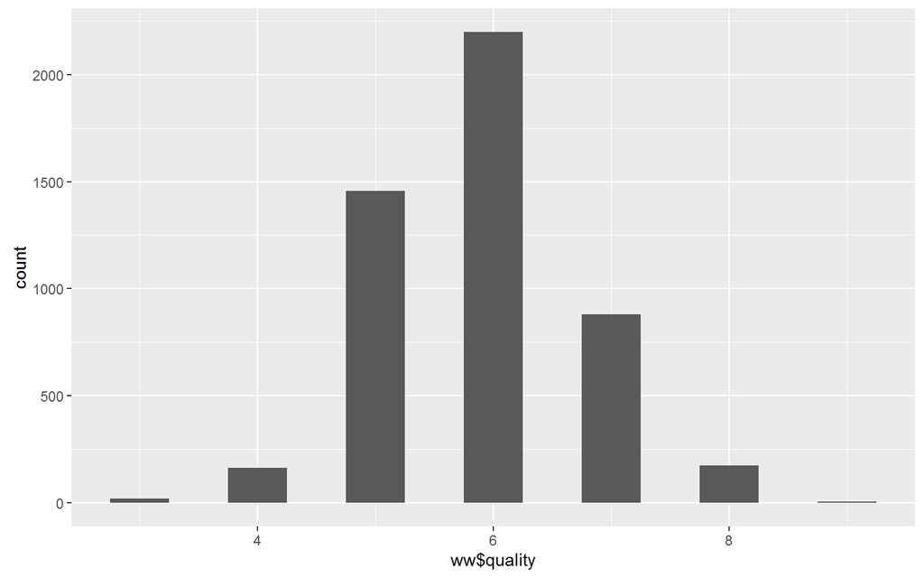

As observer before, quality have integer values concentrated between 4 and 8. Next we bucket those quality factors in Poor, Fair, Good, Vgood and Excelent, joining 3 with 4 and 8 with 9 qualities.

```
##  Factor w/ 5 levels "POOR","FAIR",..: 3 3 3 3 3 3 3 3 3 3 ...
```

### Input variables analysis

My analysis is based on the output variable quality, so besides looking at histograms for each input variable individually, I try to look how they are related with quality by using boxplots.

- fixed acidity

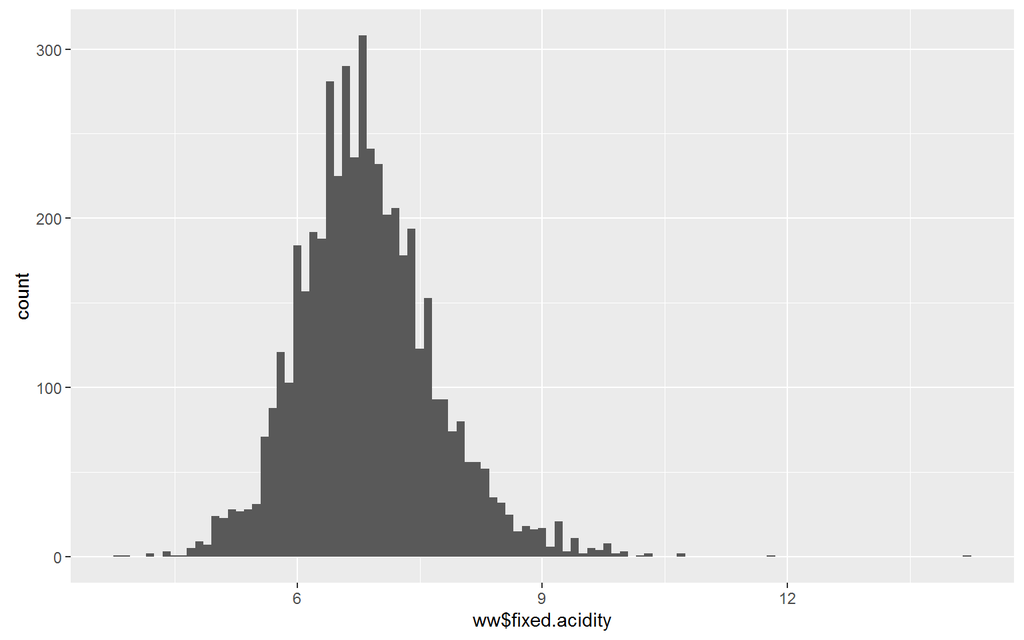

```
##    Min. 1st Qu.  Median    Mean 3rd Qu.    Max.
##   3.800   6.300   6.800   6.855   7.300  14.200
```

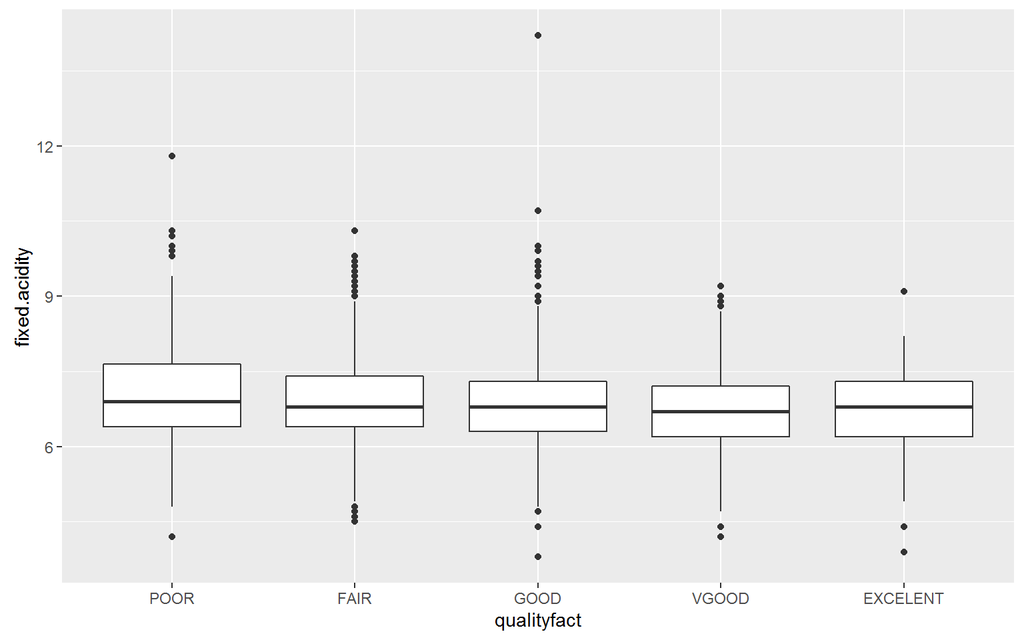

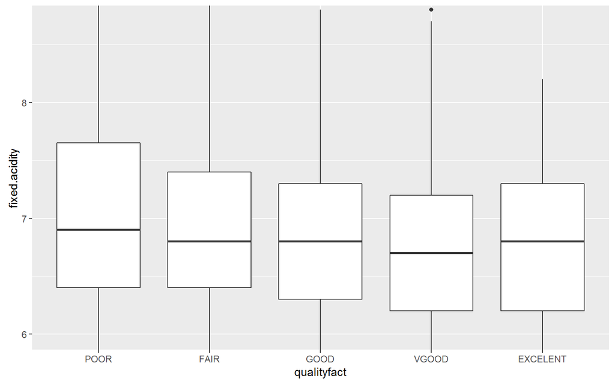

```
##   qualityfact     mean median        sd
## 1        POOR 7.180874    6.9 1.1718846
## 2        FAIR 6.933974    6.8 0.8384326
## 3        GOOD 6.837671    6.8 0.8374419
## 4       VGOOD 6.734716    6.7 0.7556702
## 5    EXCELENT 6.678333    6.8 0.8306473
```

There is not real trend here, as excelent, fair and good wines have the same medians (6.8). The poor column shows that it is better to have lower fixed acidity than too high.

- Volatile acidity

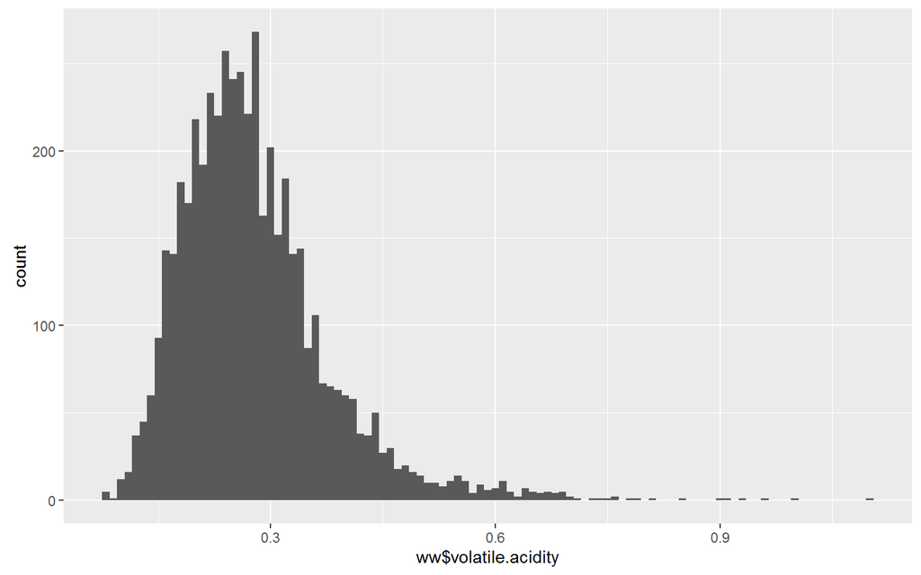

```
##    Min. 1st Qu.  Median    Mean 3rd Qu.    Max.
##  0.0800  0.2100  0.2600  0.2782  0.3200  1.1000
```

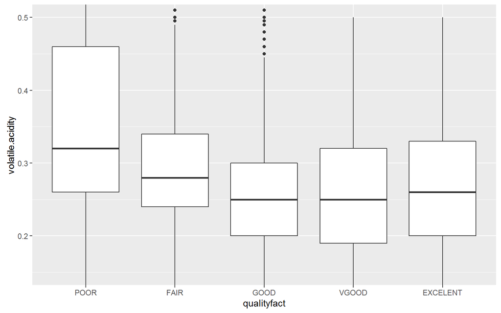

```
##   qualityfact      mean median         sd
## 1        POOR 0.3759836   0.32 0.17052477
## 2        FAIR 0.3020110   0.28 0.10006628
## 3        GOOD 0.2605641   0.25 0.08814208
## 4       VGOOD 0.2627670   0.25 0.09110644
## 5    EXCELENT 0.2779722   0.26 0.10691157
```

I see a long tailed (max = 1.1) normal distribution with mean = 0.278. I also see the effect of the `vinegar smell` here in the poor and fair categories mentioned in the dataset description: too much volatile acidity can give the wine an unpleasent smell. The plot says that it is a good idea to have volatile acidity around 0.25, and definetly not higher than 0.3.

- citric acid

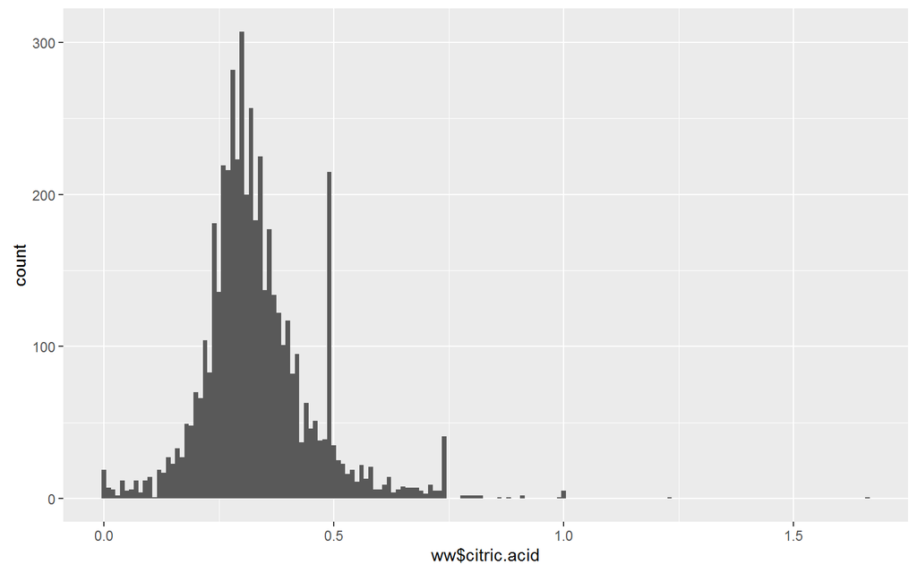

```
##    Min. 1st Qu.  Median    Mean 3rd Qu.    Max.
##  0.0000  0.2700  0.3200  0.3342  0.3900  1.6600
```

Citric acid is also normally distributed (mean = 0.3342) with 75% of datapoints below 0.39$\frac{g}{dm^3}$, but there is an intriguing large spike at 0.5. This makes me wonder if 0.5 is related with a particular quality of wine.

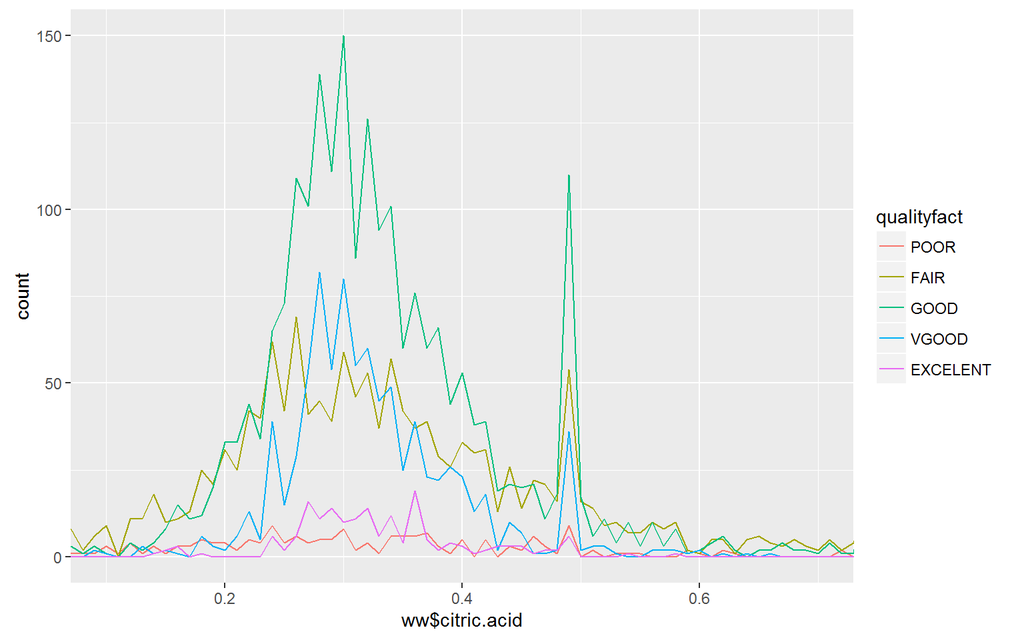

The frequency polygon plot shows that this values is not particulary related with any quality. Dead end. Let’s look at boxplots.

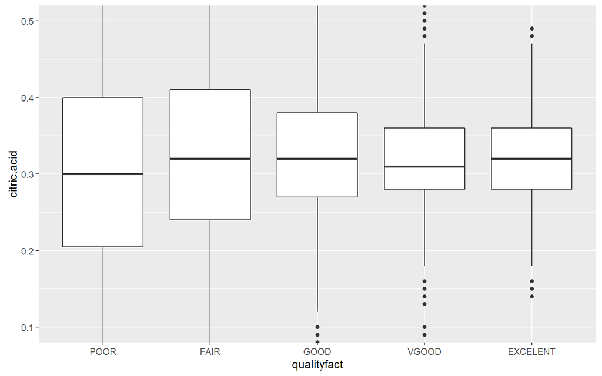

```
##   qualityfact      mean median         sd
## 1        POOR 0.3077049   0.30 0.15713150
## 2        FAIR 0.3376527   0.32 0.14081389
## 3        GOOD 0.3380255   0.32 0.11932451
## 4       VGOOD 0.3256250   0.31 0.07918280
## 5    EXCELENT 0.3281667   0.32 0.08568798
```

Here is the citric taste of the wine. Overall, all quality categories have the same median of 0.32, except poor category which has a smaller mean (0.3 < 0.33).This indicates that wine needs a minimum ammount of citric acid to be better classified. Particulary, wines that have less than 0.32 $\frac{g}{dm^3}$ are more likely to be in the poor category.

- pH

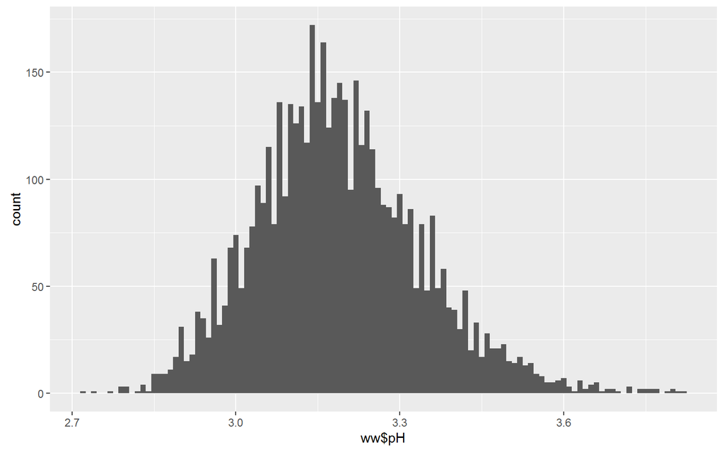

```
##    Min. 1st Qu.  Median    Mean 3rd Qu.    Max.
##   2.720   3.090   3.180   3.188   3.280   3.820
```

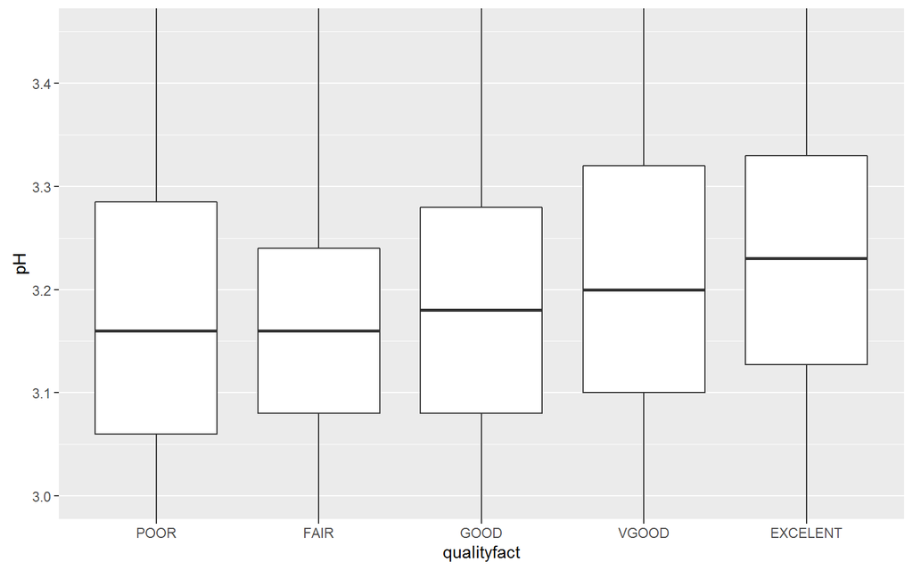

```
##   qualityfact     mean median        sd
## 1        POOR 3.183388   3.16 0.1686680
## 2        FAIR 3.168833   3.16 0.1408954
## 3        GOOD 3.188599   3.18 0.1509962
## 4       VGOOD 3.213898   3.20 0.1584019
## 5    EXCELENT 3.221167   3.23 0.1513746
```

pH is normally distribute with mean = 3.188 and 75% of the values bellow 3.28. Box plots shows that the larger the pH, wines are most likelly to be good ones. This is most certainly related to the fixed acidity variable because of chemical definition of pH. We explore correlations later.

- free sulfur dioxide

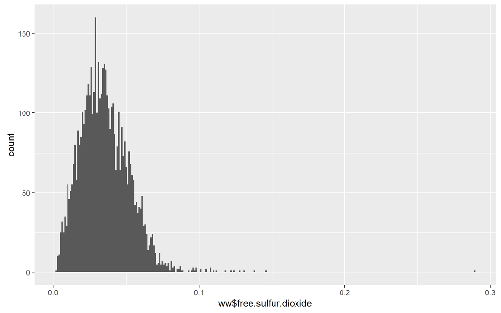

```
##    Min. 1st Qu.  Median    Mean 3rd Qu.    Max.
## 0.00200 0.02300 0.03400 0.03531 0.04600 0.28900
```

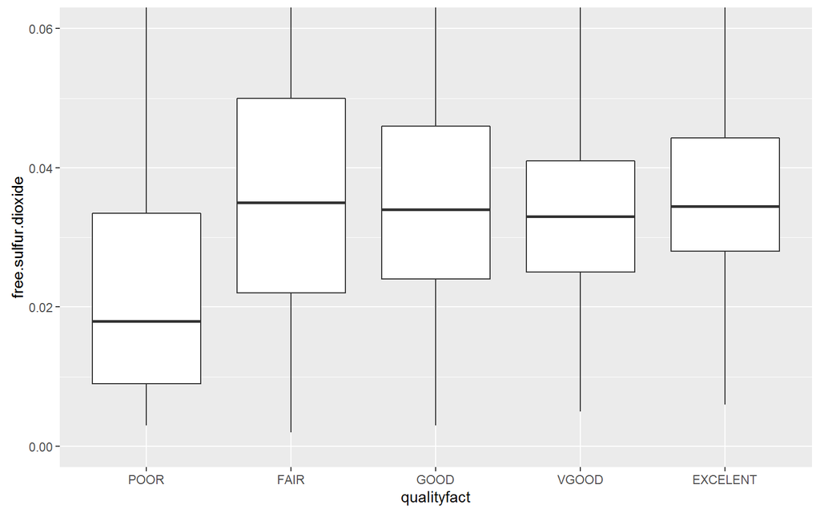

```
##   qualityfact       mean median         sd
## 1        POOR 0.02663388 0.0180 0.03100186
## 2        FAIR 0.03643205 0.0350 0.01814599
## 3        GOOD 0.03565059 0.0340 0.01573568
## 4       VGOOD 0.03412557 0.0330 0.01324474
## 5    EXCELENT 0.03662778 0.0345 0.01611066
```

- total sulfur dioxide

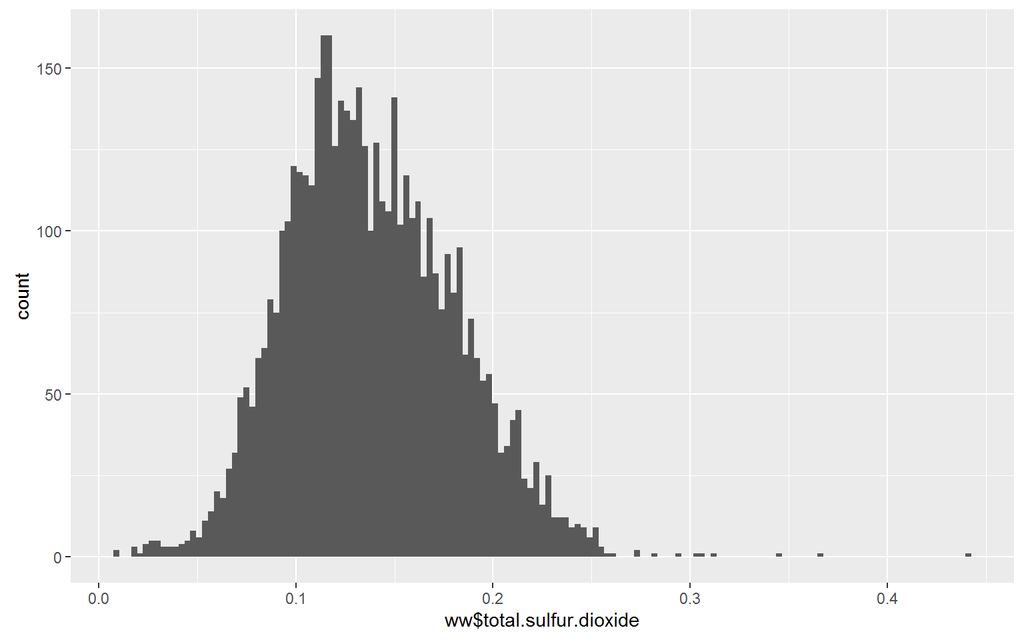

```
##    Min. 1st Qu.  Median    Mean 3rd Qu.    Max.
##  0.0090  0.1080  0.1340  0.1384  0.1670  0.4400
```

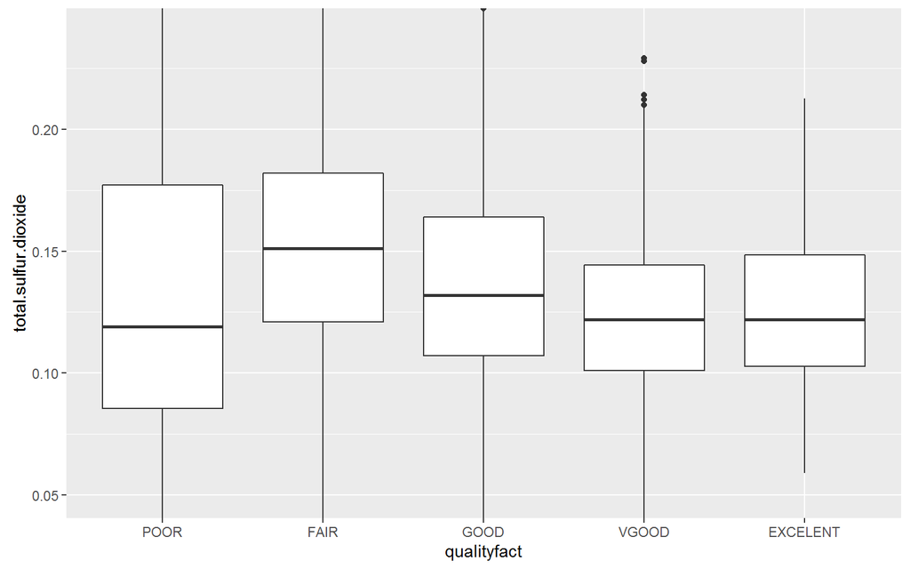

```
##   qualityfact      mean median         sd
## 1        POOR 0.1302322  0.119 0.06237316
## 2        FAIR 0.1509046  0.151 0.04408619
## 3        GOOD 0.1370473  0.132 0.04128622
## 4       VGOOD 0.1251148  0.122 0.03274298
## 5    EXCELENT 0.1258833  0.122 0.03271965
```

Normal distribution with mean = 0.138 and 75% of values below 0.167. Total sulfur dioxide affects the taste of the wine in high concentrations (fair and good categories). Too few total sulfur dioxide can indicate low free sulfur dioxide (spoiled wines). Data shows that around 0.122 $\frac{g}{dm^3}$ is a good target for this variable.

- sulphates

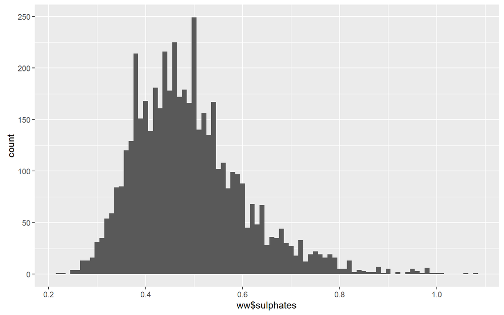

```
##    Min. 1st Qu.  Median    Mean 3rd Qu.    Max.
##  0.2200  0.4100  0.4700  0.4898  0.5500  1.0800
```

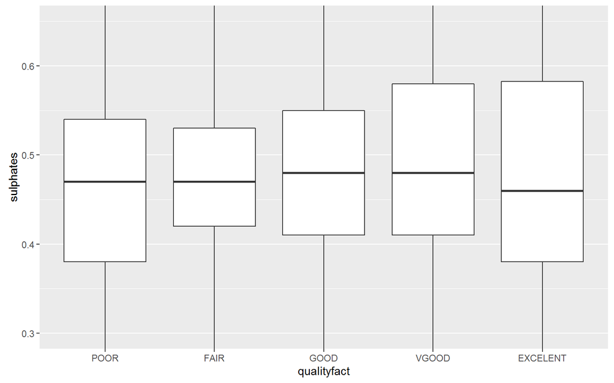

```
##   qualityfact      mean median         sd
## 1        POOR 0.4759563   0.47 0.11784716
## 2        FAIR 0.4822032   0.47 0.09820514
## 3        GOOD 0.4911056   0.48 0.11335696
## 4       VGOOD 0.5031023   0.48 0.13019470
## 5    EXCELENT 0.4856667   0.46 0.14570231
```

Sulphates are normally distributed with mean = 0.489 and 75% of values below 0.55. I don’t see any noticeable relation with quality on boxplots.

- density

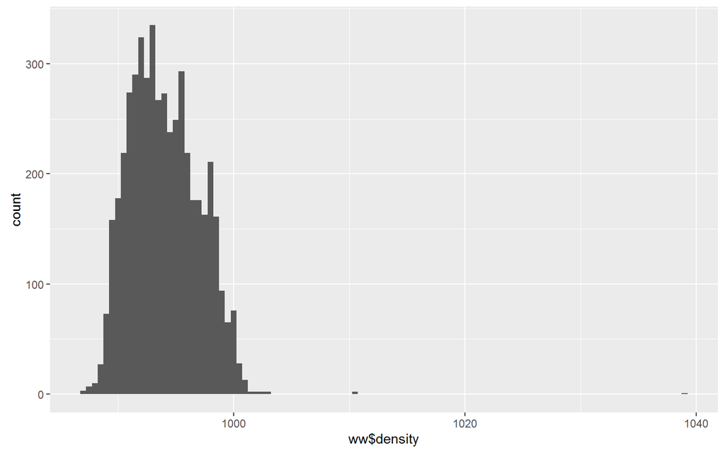

```
##    Min. 1st Qu.  Median    Mean 3rd Qu.    Max.
##   987.1   991.7   993.7   994.0   996.1  1039.0
```

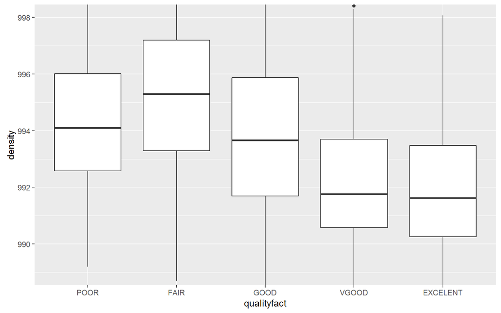

```
##   qualityfact     mean median       sd
## 1        POOR 994.3431 994.10 2.503890
## 2        FAIR 995.2626 995.30 2.544734
## 3        GOOD 993.9613 993.66 3.023510
## 4       VGOOD 992.4524 991.76 2.767670
## 5    EXCELENT 992.2144 991.62 2.790695
```

Density is normally distributed with mean = 994 and 75% of values are below 996. The boxplot shows a large trend, which says that the smaller the density, wines are more likely to have better quality. Density is related to the amount of alcohol and sugar in the mixture, which is related with the fermentation process. We investigate more on that later.

- chlorides

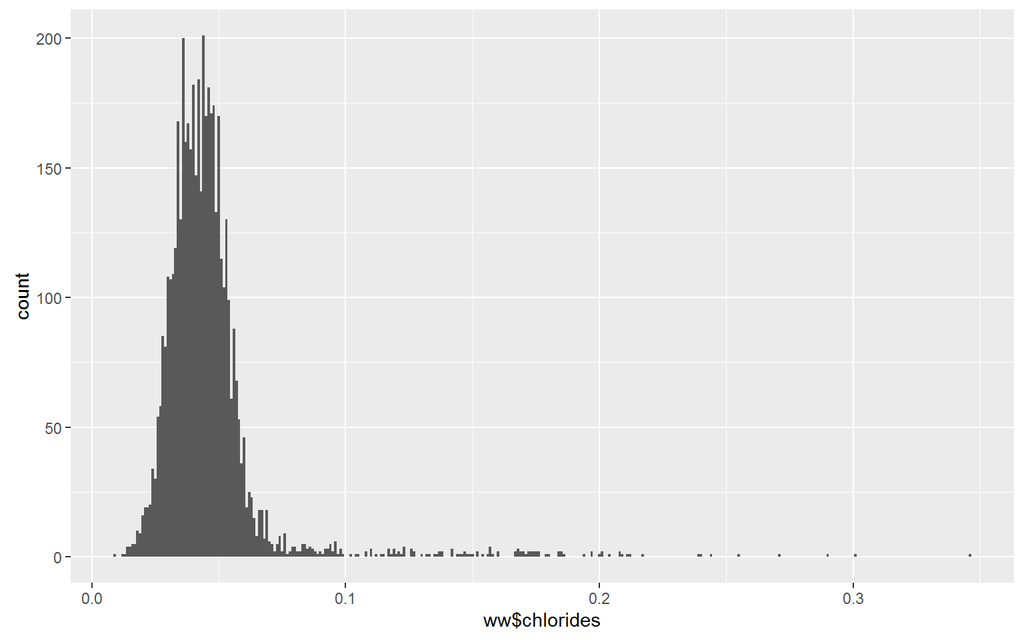

```
##    Min. 1st Qu.  Median    Mean 3rd Qu.    Max.
## 0.00900 0.03600 0.04300 0.04577 0.05000 0.34600
```

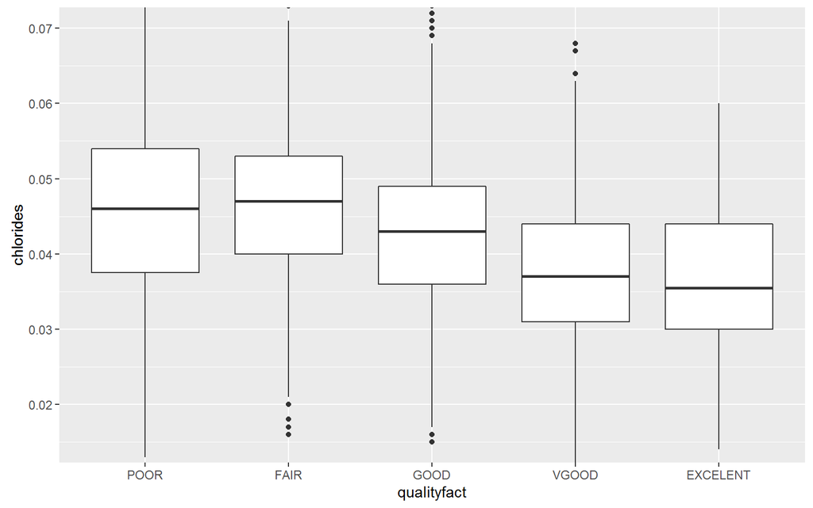

```
##   qualityfact       mean median         sd
## 1        POOR 0.05055738 0.0460 0.02869996
## 2        FAIR 0.05154633 0.0470 0.02649561
## 3        GOOD 0.04521747 0.0430 0.02045288
## 4       VGOOD 0.03819091 0.0370 0.01069741
## 5    EXCELENT 0.03801111 0.0355 0.01314976
```

The distribution is normal with a long tail for high values. Mean = 0.045 and 75% of datapoints are below 0.05. The smaller the amount of chlorides, larger the probability of having a good wine.

- alcohol

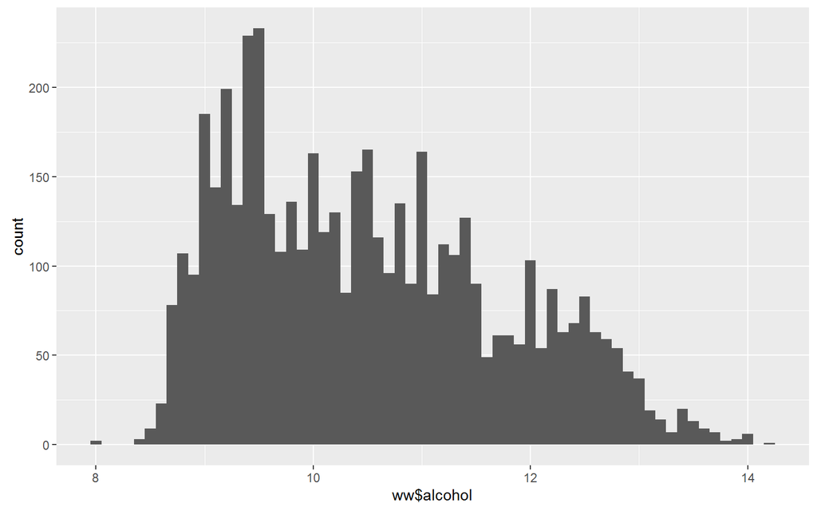

```
##    Min. 1st Qu.  Median    Mean 3rd Qu.    Max.
##    8.00    9.50   10.40   10.51   11.40   14.20
```

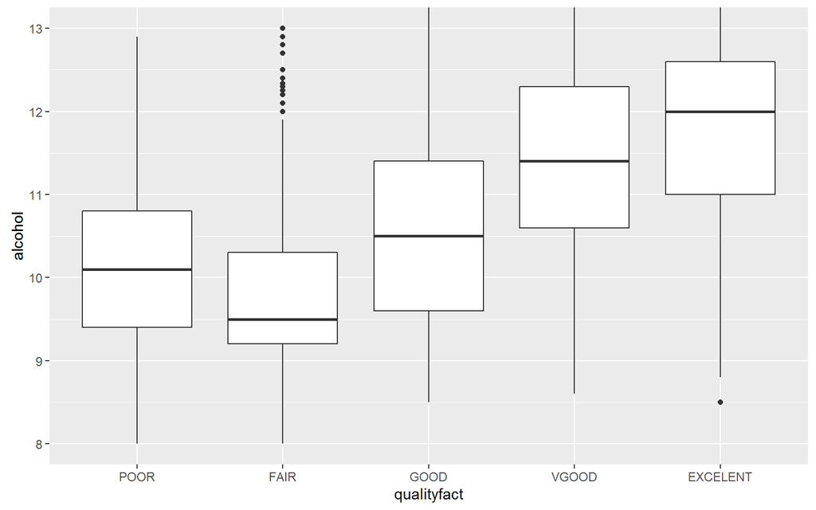

```
##   qualityfact     mean median        sd
## 1        POOR 10.17350   10.1 1.0275704
## 2        FAIR  9.80884    9.5 0.8470653
## 3        GOOD 10.57537   10.5 1.1477762
## 4       VGOOD 11.36794   11.4 1.2465358
## 5    EXCELENT 11.65111   12.0 1.2743489
```

Alcohol has a more flat distribution, skewed for smaller values. Mean is 10.51 and 75% of values ae below 11.4. The median per quality shows a spread of 2.5% of alcohol volume in the median, comparing FAIR and EXCELENT wines. Together with density , this is the largest trend seen so far. Let’s investigate it a little further:

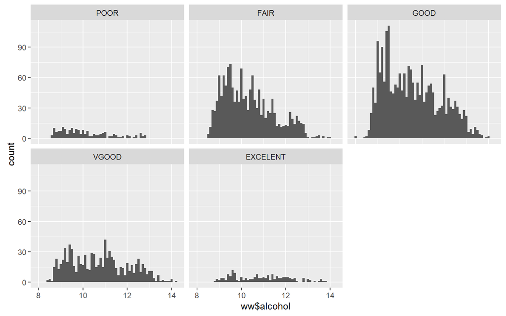

It’s hard to tell any trend here because counts are so different. Let’s try a density plot:

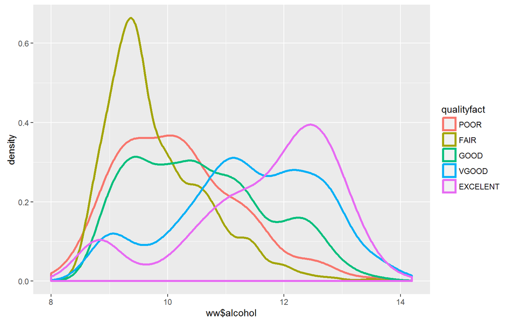

Now I can clearly see the skewness of distribution for each quality. POOR and FAIR wines are skewed to the left (low alcohol values), while VGOOD and EXCELENT are skewed to large values. GOOD is in the middle, more to low values.

Let’s see how it relates to the other large trend: density.

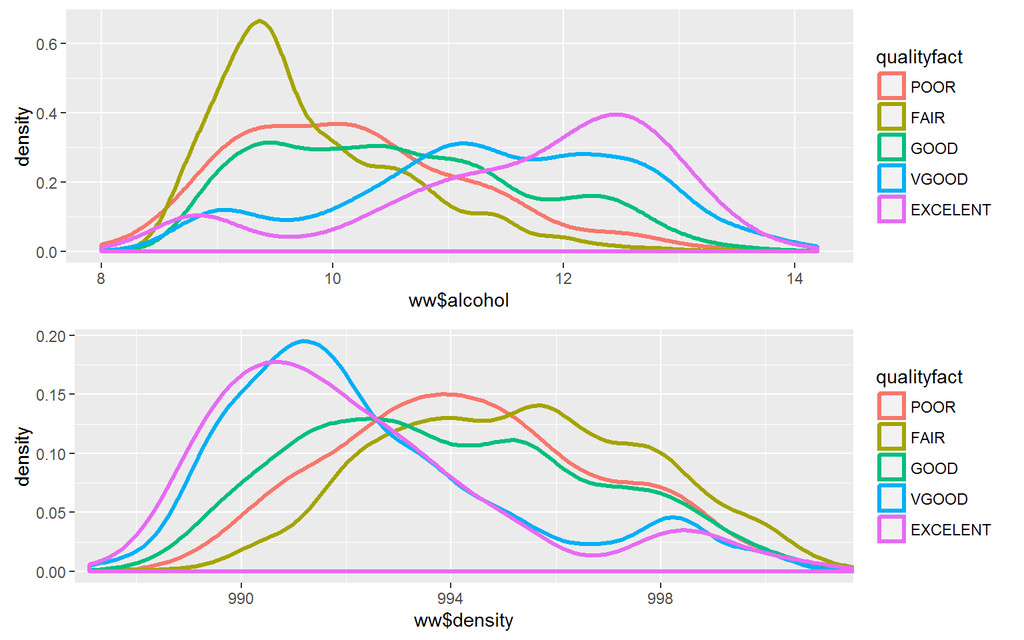

Density plot shows that trends are negatively correlated. More on that later.

- residual sugar

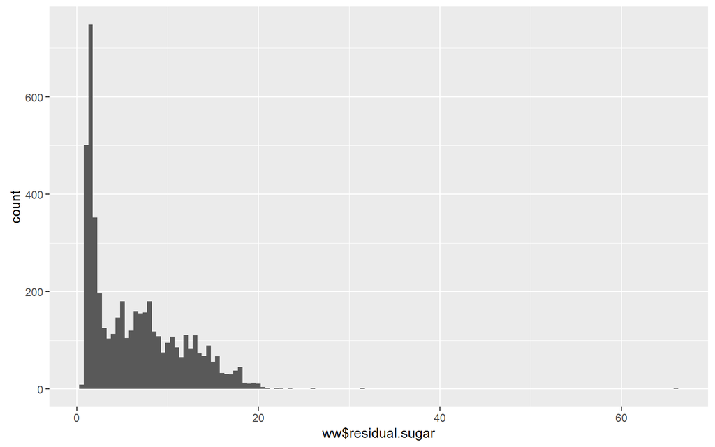

Distribution is highly skewed. I’ve applied a log transformation to see what happens.

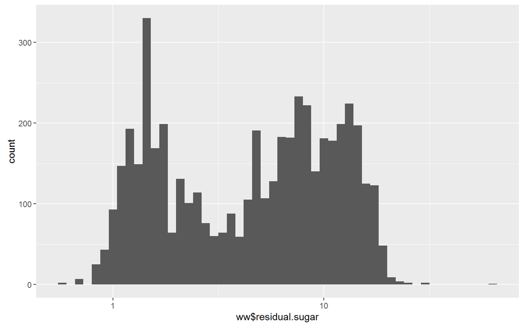

```
##    Min. 1st Qu.  Median    Mean 3rd Qu.    Max.
##   0.600   1.700   5.200   6.391   9.900  65.800
```

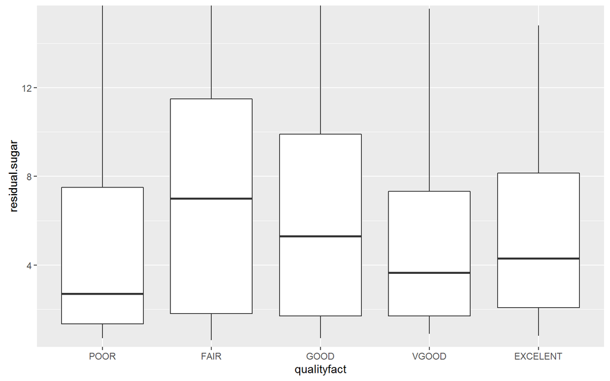

```
##   qualityfact     mean median       sd
## 1        POOR 4.821038   2.70 4.322845
## 2        FAIR 7.334969   7.00 5.327619
## 3        GOOD 6.441606   5.30 5.166625
## 4       VGOOD 5.186477   3.65 4.297989
## 5    EXCELENT 5.628333   4.30 4.248523
```

Boxplots shows a significant spread on residual sugar values. POOR wines have too little sugar(2.7), while FAIR wines have too much. Better quality wines have mean around 5.5.

## Section Summary

There are 4898 wines in the dataset with 11 input variables (X is dropped) :fixed.acidity, volatile.acidity, citric.acid, pH, total.sulphur.dioxide, free.sulphur.dioxide, sulphates, density, alcohol, residual.sugar, chlorides; and quality as an output variable. All input variables are numeric, while we generate another version for the quality variable based on 5 factors (observations in parenthesis): POOR(183), FAIR(1457), GOOD(2198), VGOOD(880) and EXCELENT(180). This was done by bucketing qualities 3 and 4 in POOR and 8 and 9 in EXCELENT, since we had very few observations in categories 3 and 9. Other interesting statistics:

- Minimum and maximun density are very close (987.1 to 1039 $\frac{g}{dm^3}$), which is close to water density.
- Median and Mean are close for all variables, except residual sugar;
- Residual sugar has a highly skewed distribution, and a log rescale shows a bimodal distribution of bitter and sweet wines.

Since most variables are approximately normally distributed (except residual), I focused the analysis on the relationship of the input variable with quality, by checking median behavior of factors in a boxplot. The most striking trends were found with alcohol and density. Those variables are related, and I expect residual.sugar to also play a role in this equation too.

Other interesting findings:

- pH has positive correlation with quality;
- the correlation of fixed acidity and quality is not clear. It should be, as I expected that pH and fixed.acidity to be highly correlated.
- wines that have less than 0.32 $\frac{g}{dm^3}$ of citric acid are more likely to be in the poor category;
- Wines usually have a median value for free sulphur dioxide of 0.035 $\frac{g}{dm^3}$, except POOR wines which have smaller values. As sulphur dioxide prevents oxidation, many of those POOR wines are probably spoiled.

So, the biggest question to me is why quality is so strongly correlated with alcohol. Saying that more alcoholic the wine the better is as infamous as saying that vodka is better than wine. Next I try to figure that out.

## Multivariate Analysis

### Correlations overview

First I want an overview of correlations between variables:

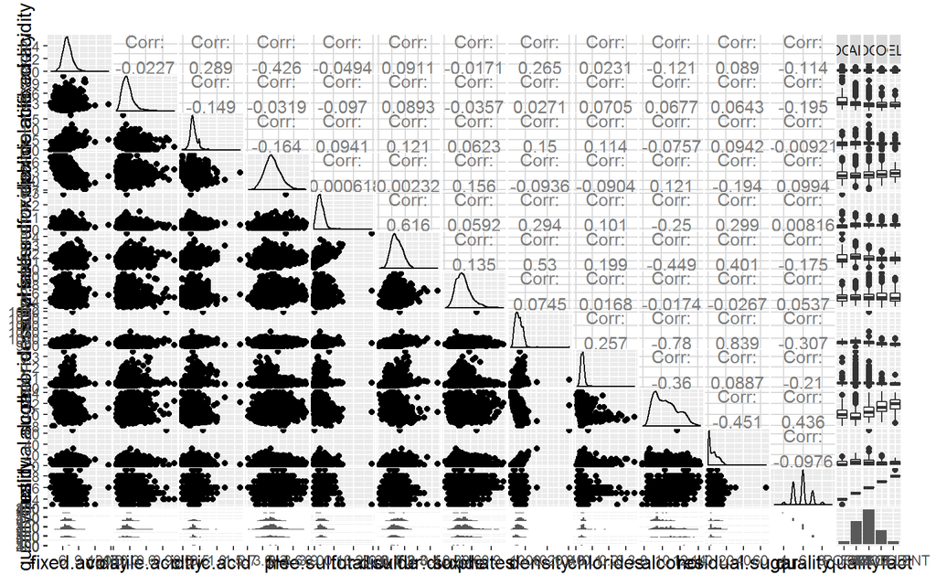

There are lots of information on this messy plot. The diagonal has the same histograms ploted previously, and last column has the previous boxplots. I will split this plot on 3 subplots in the following, grouping by category: density, acidity and sulphates.

- density

First I look for the largest correlation values, and indeed they show up around alcohol and density (-0.78), residual.sugar and density (0.84) alcohol and sugar (-0.45) and alcohol and chlorides (-0.36).

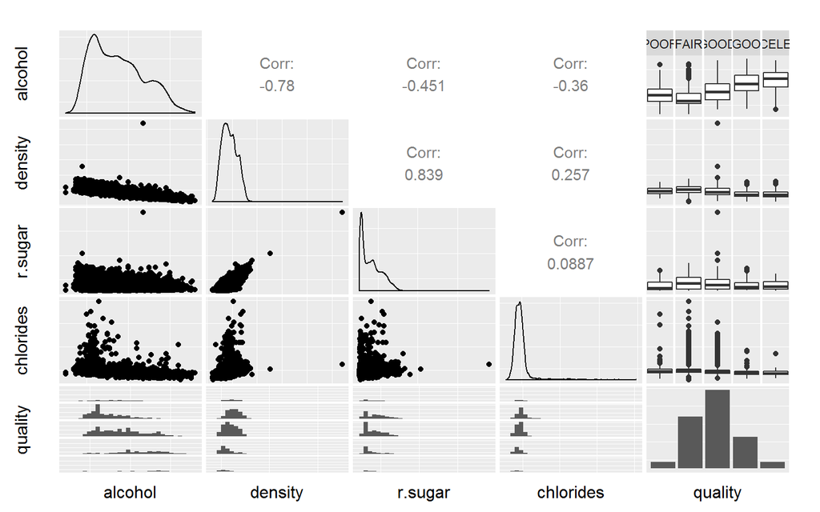

Those correlations can be explained in principle, as sugar, alcohol and chlorides have the largest concentrations involved in wine composition. To keep things simpler, I keep only residual sugar and alcohol, discarding the less important chlorides from this analysis. So we try a linear model with two variables for density outcome next.

```
##
## Call:
## lm(formula = ww$density ~ ww$alcohol + ww$residual.sugar, data = ww)
##
## Residuals:
##     Min      1Q  Median      3Q     Max
## -2.0196 -0.5852 -0.1403  0.4674 24.9805
##
## Coefficients:
##                     Estimate Std. Error t value Pr(>|t|)
## (Intercept)        1.005e+03  1.349e-01  7446.7   <2e-16 ***
## ww$alcohol        -1.226e+00  1.188e-02  -103.2   <2e-16 ***
## ww$residual.sugar  3.607e-01  2.884e-03   125.1   <2e-16 ***
## ---
## Signif. codes:  0 '***' 0.001 '**' 0.01 '*' 0.05 '.' 0.1 ' ' 1
##
## Residual standard error: 0.9137 on 4895 degrees of freedom
## Multiple R-squared:  0.9067, Adjusted R-squared:  0.9067
## F-statistic: 2.379e+04 on 2 and 4895 DF,  p-value: < 2.2e-16
```

Adjusted R-squared is 0.90, which is pretty good. We can visualize the fit with a 3D plot.

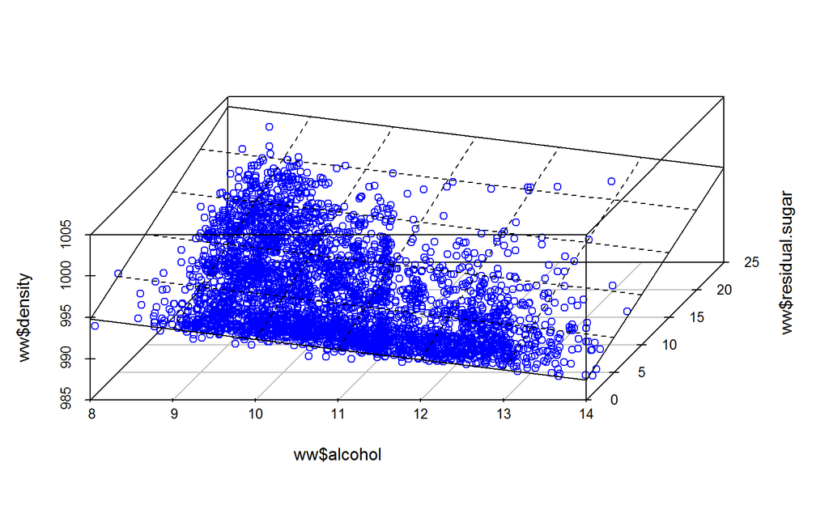

The plane is correspondent to the linear model, and the fact that most of the data lie on this 3D plane means that the model is pretty good.